# Baseball Questions

Thomas Van Zuiden

March 21, 2017

```r
library(Lahman)
data(Batting)
names(Batting)
nrow(Batting)  ## 101332
ncol(Batting) ## 22
library(dplyr)
library(tidyr)
```

# 1 Using Lahman MLB data in R, list the top 5 teams since 2000 with the largest stolen bases per at bat ratio

#### Creating a workable data frame

```r
df <- Batting
df1 <- newdata <- subset(df, yearID >= 2000) # Select years equal to, or greater than 2000
SBperAB <- df1$SB/df1$AB # Create the "Stolen bases per at bat" ratio variable
df1 <- data.frame(df1, SBperAB) # Add the "Stolen bases per at bat" variable to the data frame
names(df1)
df1[!is.finite(df1$SBperAB),"SBperAB"] <- 0  # Call "inf" values "0"
nrow(df1) ## 22084
df1<-data.frame(df1)
```

```r
test <- aggregate(SBperAB ~ teamID+yearID, data=df1, FUN=mean)
head(test)
```

```r
sort1 <- test[order(test$yearID, -test$SBperAB), ]
```

#### Sorting by Stolen bases per at bat shifts rows around, so I rename them here

```r
rownames(sort1) <- c(1:nrow(sort1))
sort2 <- aggregate(sort1[,"teamID"] ~ yearID, data=sort1, FUN=head)
sort2 <- data.frame(sort2[,1],sort2$sort1[,1:5]) ## Did this because the "FUN=head" above gives the top 6 teams per year, and I want the top 5
colnames(sort2) <- c("yearID","1st","2nd","3rd","4th","5th") ## Making the table "presentable"
```

## Final answer for Q1, displaying the 5 teams with the best Stolen Bases per At Bat values for each year between 2000 to 2015

```r
sort2
```

```
##    yearID 1st 2nd 3rd 4th 5th
## 1    2000 DET SEA CIN COL BAL
## 2    2001 ATL BAL NYA TOR SEA
## 3    2002 SEA ANA TEX OAK MON
## 4    2003 SEA NYA ANA TBA FLO
## 5    2004 HOU KCA SFN MIN TBA
## 6    2005 MIL TEX PIT HOU TBA
## 7    2006 HOU LAA LAN NYA FLO
## 8    2007 MIL SEA SFN NYN LAA
## 9    2008 SFN PHI CHA TBA NYN
## 10   2009 NYA COL WAS TBA CHA
## 11   2010 TBA TEX CHA SDN KCA
## 12   2011 SFN SDN KCA ATL FLO
## 13   2012 WAS NYA TBA MIL SFN
## 14   2013 CIN KCA BOS SDN WAS
## 15   2014 KCA OAK BAL NYA MIN
## 16   2015 CHN NYA KCA PIT NYN
```

# 2. Using this same Batting data, plot the yearly SBperAB rate. This will be computed over the entire year rather than per team-year as above

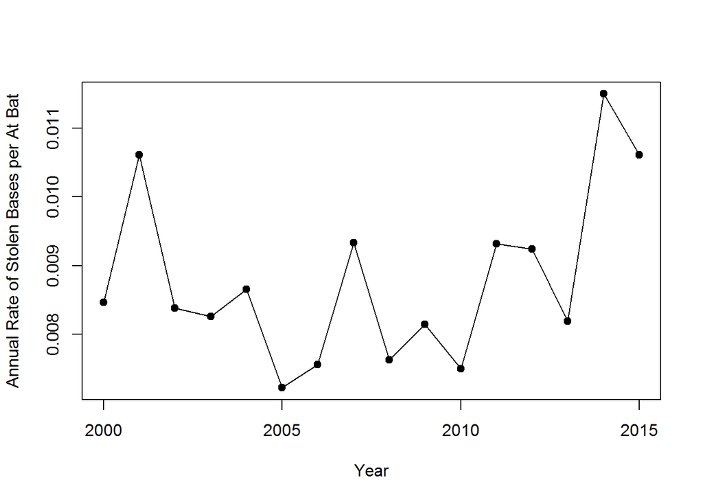

```r
yearlyABperSB <- aggregate(SBperAB ~ yearID, data=df1, FUN=mean)
plot(yearlyABperSB, type = "o", pch=19, xlab="Year", ylab="Annual Rate of Stolen Bases per At Bat")
```

# 2a. Same plot but color each plot by lgID (LeagueID). For this problem we only care about NL and AL, everything else can be filtered out.

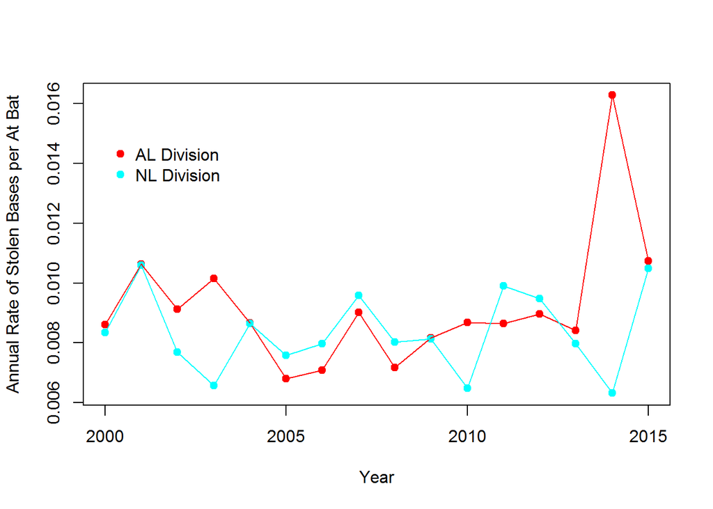

```r
yearlyABperSB2 <- aggregate(SBperAB ~ yearID*lgID, data=df1, FUN=mean)
plot(yearlyABperSB2$yearID, yearlyABperSB2$SBperAB, col=as.factor(yearlyABperSB2$lgID), pch=19, xlab="Year", ylab="Annual Rate of Stolen Bases per At Bat")
lines(SBperAB ~ yearID, col=as.factor(lgID), data = subset(yearlyABperSB2, lgID=="AL"), lty = 'solid')
lines(SBperAB ~ yearID, col=as.factor(lgID), data = subset(yearlyABperSB2, lgID=="NL"), lty = 'solid')
legend(2000,0.015, c("AL Division","NL Division"), pch=19, col=c(2,5), bty="n")
```

# 3. Use this Year, SB.PerAB dataset (generated in #2 above) to create a model for how year relates to SB.PerAB. In this problem you are using only yearID to predict SB.PerAB. Try a few model fits and determine which one is best.

```r
hist(yearlyABperSB$SBperAB) ## determine destribution of SBperAB, not important to the answer
```

```r
library(randomForest)
library(gbm) ### Sample size ended up being too small to run a boosted regression
library(tseries)
```

### General linear regression model

```r
mod1 <- lm(SBperAB ~ yearID, data=yearlyABperSB)
summary(mod1)
```

```
##
## Call:
## lm(formula = SBperAB ~ yearID, data = yearlyABperSB)
##
## Residuals:
##        Min         1Q     Median         3Q        Max
## -1.496e-03 -1.065e-03  6.125e-05  3.701e-04  2.363e-03
##
## Coefficients:
##               Estimate Std. Error t value Pr(>|t|)
## (Intercept) -1.583e-01  1.324e-01  -1.196    0.252
## yearID       8.325e-05  6.596e-05   1.262    0.228
##
## Residual standard error: 0.001216 on 14 degrees of freedom
## Multiple R-squared:  0.1022, Adjusted R-squared:  0.03804
## F-statistic: 1.593 on 1 and 14 DF,  p-value: 0.2275
```

#### The Rsquared value of this model is a 0.1

### Random Forest model

```r
mod2 <- randomForest(SBperAB ~ yearID, data = yearlyABperSB)
print(mod2)
```

```
##
## Call:
##  randomForest(formula = SBperAB ~ yearID, data = yearlyABperSB)
##                Type of random forest: regression
##                      Number of trees: 500
## No. of variables tried at each split: 1
##
##           Mean of squared residuals: 1.548992e-06
##                     % Var explained: -7.45
```

#### The Rsquared value of this model is a negative number, which indicates that the random forest is not explaining any variation between Year and SBperAB

### Time-series model — autoregressive moving average (ARMA)

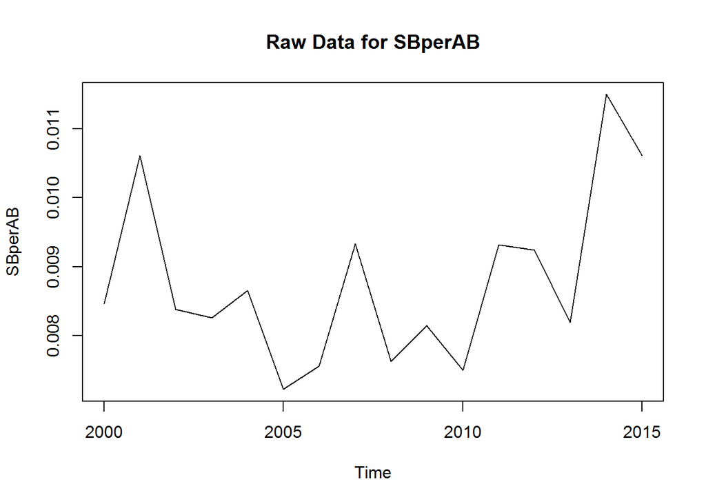

```r
plot(yearlyABperSB,type="l",main="Raw Data for SBperAB" ,xlab="Time",ylab="SBperAB")
```

### Determine if SBperAB is temporally autocorrelated

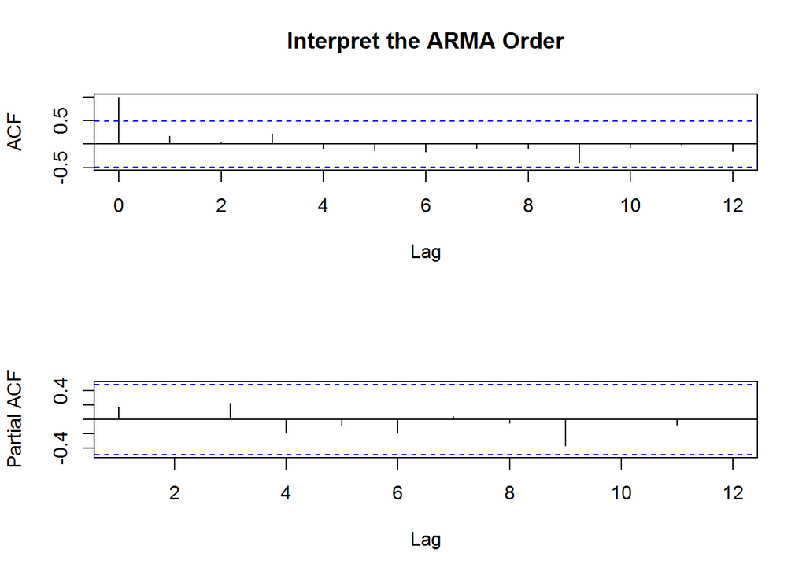

```r
par(mfrow=c(2,1))
acf(yearlyABperSB[,2],main="Interpret the ARMA Order")
pacf(yearlyABperSB[,2],main="")
```

#### We can see that SBperAB is not correlated through time. Normally this would indicate that running time-series models would not be appropriate

#### I’ll run a couple anyway just to show I can

```r
(mod3 <- arima(yearlyABperSB[,2],order=c(1,0,0))) # Better model, due to lower AIC value (-164.32 is lower than -162.51)
```

```
##
## Call:
## arima(x = yearlyABperSB[, 2], order = c(1, 0, 0))
##
## Coefficients:
##         ar1  intercept
##       0.190     0.0088
## s.e.  0.257     0.0004
##
## sigma^2 estimated as 1.391e-06:  log likelihood = 85.16,  aic = -164.32
```

```r
(mod4 <- arima(yearlyABperSB[,2],order=c(1,0,1)))
```

```
##
## Call:
## arima(x = yearlyABperSB[, 2], order = c(1, 0, 1))
##
## Coefficients:
##          ar1      ma1  intercept
##       0.6243  -0.4229     0.0089
## s.e.  0.5276   0.5332     0.0005
##
## sigma^2 estimated as 1.372e-06:  log likelihood = 85.25,  aic = -162.51
```

#### Both of these models don’t really work, but mod3 is stronger than mod4 because it has a lower AIC value

#### The R-square of this model (its fit) would be 0.19^2, which means, Rsquared=0.036

### The fit of these models is extremely low. Low fit makes sense, as Stolen Bases per At Bat should not be dependent on Year. With that said however, the best model is “mod1”. I would not trust any of these models in a predictive capacity though

# 4 A baseball player is said to be continuously playing if he’s playing for *consecutive years. Given the years that some baseball player played in, write the function activeYears which computes the sequence of the lengths of the continuous playing.

```r
activeYears <- function(x) {
  cumdiff<- cumsum(c(1, diff(x)>1))
  vals <- rle(cumdiff)$lengths
  return(vals)
}
years <- c(1994,1995,1996,1998,1999,2000,2001,2003,2004,2006)
(pleasework <- activeYears(years))
```

```
## [1] 3 4 2 1
```

### checking to see what it should be… looks like 1 5 2 1 for aardsda01

```r
df1[df1$playerID=="aardsda01", "yearID"]
```

### Testing the function

```r
activeYears(df1[df1$playerID=="aardsda01", "yearID"])
```

```
## [1] 1 5 2 1
```